# e-Rum2020 - Semantic Web in R for Data Scientists

Goran S. Milovanović, Phd

DataKolektiv, Chief Scientist & Owner, Wikimedia Deutschland, Data Scientist

2020 06 20

# Notebook 00: Intro to Semantic Web in R for Data Scientists

**Feedback** should be send to `goran.milovanovic@datakolektiv.com`.

These notebooks accompany the e-Rum2020: Semantic Web in R for Data Scientists Workshop, 2020/06/20.

**To obtain these notebooks:** `git clone` datakolektiv/e-Rum2020_SemanticWeb.

## 0. Prerequisites/Installations

We have some installations to complete first. This should take no time at all.

### 0.1 Install {rdflib} + dependencies

#### Ubuntu/Debian

For **Ubuntu/Debian**, open the terminal and install `librdf0-dev`:

`sudo apt-get install librdf0-de`

so that {rdflib} can rely on [{redland}](https://cran.r-project.org/web/packages/redland/index.html) - an R interface to the [Redland RDF C library](http://librdf.org/docs/api/index.html).

Then: `install.packages('rdflib')` from your R session. Also, please `install.packages('jsonld')` - the [{jsonld}](https://cran.r-project.org/web/packages/jsonld/index.html) package that parses JSON-LD, a semantic web flavour of JSON (JSON-LD == JSON for Linked Data).

#### Windows

Windows users should be able to install *everything* by just doing `install.packages()`. When installing {rdflib} accept installing from source when prompted.

### [OPTIONAL] 0.2 Install {rrdf} + dependencies

Following the instructions from https://github.com/egonw/rrdf

You will need [{devtools}](https://cran.r-project.org/web/packages/devtools/index.html) if not already installed (and if not… `install.packages('devtools')`), and [{rJava}](https://cran.r-project.org/web/packages/rJava/index.html) (`install.packages('rJava')`).

Then:

`devtools::install_github("egonw/rrdf", subdir="rrdflibs")` `devtools::install_github("egonw/rrdf", subdir="rrdf", build_vignettes = FALSE)`

This will install the [{rrdf}](https://github.com/egonw/rrdf) package to handle RDF + [{rrdflibs}](https://github.com/egonw/rrdf/tree/master/rrdflibs): the [Apache Jena](https://jena.apache.org/) libraries. Long story shor: Apache Jena is *“… a free and open source Java framework for building Semantic Web and Linked Data applications”*, while {rrdf} wraps R around it. We will rely more on the {rdflib} package (instaled in section `0.1`) in this Notebook ({rrdf} is not on CRAN anymore, and I have no idea if it is maintained anymore). However, Apache Jena itself is very popular.

### 0.3 {jsonlite} to parse JSON and {SPARQL}

`install.packages('jsonlite')` `install.packages('SPARQL')`

### 0.4 Wikidata and Wikipedia related packages

`install.packages('WikidataR')` `install.packages('WikidataQueryServiceR')` `install.packages('WikipediR')`

### 0.5 {visNetwork} for graph visualizations and {leaflet} for maps

Install {visNetwork} for graph visualizations using [vis.js](http://visjs.org/) javascript library:

`install.packages('visNetwork')` `install.packages('leaflet')`

### 0.6 Recommended reading

[A tidyverse lover’s intro to RDF](https://cran.r-project.org/web/packages/rdflib/vignettes/rdf_intro.html#fn2) - Carl Boettiger’s [{rdflib}](https://cran.r-project.org/web/packages/rdflib/index.html) vignette. This notebook expands upon what Carl Boettiger’s excellent vignette explains about {rdflib}.

### 0.7 Setup

**Note.** The following chunk loads the packages and defines the project directory tree.

```r
# - Directory tree
dataDir <- '../_data/'
queryDir <- '../_queries/'
analyticsDir <- '../_analytics/'

# - Packages
library(tidyverse)
library(httr)
library(jsonlite)
library(rdflib)
library(SPARQL)
library(scales)
library(visNetwork)
library(leaflet)
```

## 1. Transform a `dataframe` into an RDF adherent graph representation and back

**The roadmap.** We want to start from an R `data.frame` class, a form of data representation well-known to Data Scientists, transform it to a graph in compliance with the [RDF (Resource Description Framework)](https://www.w3.org/RDF/) Semantic Web standard, store in an in-memory [triplestore](https://en.wikipedia.org/wiki/Triplestore) with {rdflib}, and query it with [SPARQL](https://www.w3.org/TR/rdf-sparql-query/) query language for RDF.

Let’s use the well-known [`mtcars`](https://stat.ethz.ch/R-manual/R-devel/library/datasets/html/mtcars.html) dataset.

### 1.1 Crash `mtcars`: a `dataframe` goes into a triplestore

```r
data(mtcars)
head(mtcars, 5)
```

|  | mpg | cyl | disp | hp | drat | wt | qsec | vs | am | gear | carb |
| --- | --- | --- | --- | --- | --- | --- | --- | --- | --- | --- | --- |
| Mazda RX4 | 21.0 | 6 | 160 | 110 | 3.90 | 2.620 | 16.46 | 0 | 1 | 4 | 4 |
| Mazda RX4 Wag | 21.0 | 6 | 160 | 110 | 3.90 | 2.875 | 17.02 | 0 | 1 | 4 | 4 |
| Datsun 710 | 22.8 | 4 | 108 | 93 | 3.85 | 2.320 | 18.61 | 1 | 1 | 4 | 1 |
| Hornet 4 Drive | 21.4 | 6 | 258 | 110 | 3.08 | 3.215 | 19.44 | 1 | 0 | 3 | 1 |
| Hornet Sportabout | 18.7 | 8 | 360 | 175 | 3.15 | 3.440 | 17.02 | 0 | 0 | 3 | 2 |

We will begin by using `tidyr::pivot_longer()` - a new approach to a short-to-long data transform in {tidyr} - to produce a set of Subject-Predicate-Object [triples](https://en.wikipedia.org/wiki/Semantic_triple) from `mtcars`:

```r
car_triples <-
  mtcars %>%
  rownames_to_column("model") %>%
  pivot_longer(-model,
               names_to = "attribute",
               values_to = "value")
print(car_triples)
```

| model | attribute | value |
| --- | --- | --- |
| Mazda RX4 | mpg | 21.000 |
| Mazda RX4 | cyl | 6.000 |
| Mazda RX4 | disp | 160.000 |
| Mazda RX4 | hp | 110.000 |
| Mazda RX4 | drat | 3.900 |
| Mazda RX4 | wt | 2.620 |
| Mazda RX4 | qsec | 16.460 |
| Mazda RX4 | vs | 0.000 |
| Mazda RX4 | am | 1.000 |
| Mazda RX4 | gear | 4.000 |

[output cut: 342 more lines]

Still I don’t want my Subject-Predicate-Object triples to go under `Model`, `attribute`, and `value`, and moreover I do not want the data in the `model` column to play the Subject role. I want to have one **concept**, a sort of an **ID**, identified by an [URI](https://en.wikipedia.org/wiki/Uniform_Resource_Identifier) to represent the “things” here, and then `model` will be just another predicate to describe things.

```r
# - produce URIs
car_triples_0 <-
  mtcars %>%
  rownames_to_column("model") %>%
  select("model") %>%
  rownames_to_column("subject")
```

```
There were 30 warnings (use warnings() to see them)
```

```r
car_triples_0$subject <- paste0("http://e-rum2020_example.com/mtcars#",
                                car_triples_0$model)
print(car_triples_0)
```

| subject | model |
| --- | --- |
| http://e-rum2020_example.com/mtcars#Mazda RX4 | Mazda RX4 |
| http://e-rum2020_example.com/mtcars#Mazda RX4 Wag | Mazda RX4 Wag |
| http://e-rum2020_example.com/mtcars#Datsun 710 | Datsun 710 |
| http://e-rum2020_example.com/mtcars#Hornet 4 Drive | Hornet 4 Drive |
| http://e-rum2020_example.com/mtcars#Hornet Sportabout | Hornet Sportabout |
| http://e-rum2020_example.com/mtcars#Valiant | Valiant |
| http://e-rum2020_example.com/mtcars#Duster 360 | Duster 360 |
| http://e-rum2020_example.com/mtcars#Merc 240D | Merc 240D |
| http://e-rum2020_example.com/mtcars#Merc 230 | Merc 230 |
| http://e-rum2020_example.com/mtcars#Merc 280 | Merc 280 |

[output cut: 22 more lines]

Now we have an URI for each `model`. Next, add the predicate *model* to the representation, and rename to Subject-Predicate-Object:

```r
# - Subject - Predicate - Object
car_triples_0$predicate <- "model"
```

```
There were 12 warnings (use warnings() to see them)
```

```r
colnames(car_triples_0) <- c("subject", "object", "predicate")
car_triples_0 <- car_triples_0[, c("subject", "predicate", "object")]
print(car_triples_0)
```

| subject | predicate | object |
| --- | --- | --- |
| http://e-rum2020_example.com/mtcars#Mazda RX4 | model | Mazda RX4 |
| http://e-rum2020_example.com/mtcars#Mazda RX4 Wag | model | Mazda RX4 Wag |
| http://e-rum2020_example.com/mtcars#Datsun 710 | model | Datsun 710 |
| http://e-rum2020_example.com/mtcars#Hornet 4 Drive | model | Hornet 4 Drive |
| http://e-rum2020_example.com/mtcars#Hornet Sportabout | model | Hornet Sportabout |
| http://e-rum2020_example.com/mtcars#Valiant | model | Valiant |
| http://e-rum2020_example.com/mtcars#Duster 360 | model | Duster 360 |
| http://e-rum2020_example.com/mtcars#Merc 240D | model | Merc 240D |
| http://e-rum2020_example.com/mtcars#Merc 230 | model | Merc 230 |
| http://e-rum2020_example.com/mtcars#Merc 280 | model | Merc 280 |

[output cut: 22 more lines]

Finally, let’s `left_join` the `car_triples_0` with the URIs to `car_triples`, introduce Subject-Predicate-Object column names, and `rbind()` the the `car_triples` set of triples with `car_triples_0` where the values for the *model* predicate is stored.

```r
# - join URIs to car_triples
car_triples <-
  car_triples %>%
  left_join(select(car_triples_0, -predicate),
            by = c("model" = "object")) %>%
  select(-model)
```

```
There were 30 warnings (use warnings() to see them)
```

```r
colnames(car_triples) <- c("predicate", "object", "subject")
car_triples <- car_triples[, c("subject", "predicate", "object")]

# - put it together:
car_triples <- rbind(car_triples, car_triples_0)
rm(car_triples_0)
print(car_triples)
```

| subject | predicate | object |
| --- | --- | --- |
| http://e-rum2020_example.com/mtcars#Mazda RX4 | mpg | 21 |
| http://e-rum2020_example.com/mtcars#Mazda RX4 | cyl | 6 |
| http://e-rum2020_example.com/mtcars#Mazda RX4 | disp | 160 |
| http://e-rum2020_example.com/mtcars#Mazda RX4 | hp | 110 |
| http://e-rum2020_example.com/mtcars#Mazda RX4 | drat | 3.9 |
| http://e-rum2020_example.com/mtcars#Mazda RX4 | wt | 2.62 |
| http://e-rum2020_example.com/mtcars#Mazda RX4 | qsec | 16.46 |
| http://e-rum2020_example.com/mtcars#Mazda RX4 | vs | 0 |
| http://e-rum2020_example.com/mtcars#Mazda RX4 | am | 1 |
| http://e-rum2020_example.com/mtcars#Mazda RX4 | gear | 4 |

[output cut: 374 more lines]

We need URIs for the predicates too:

```r
# - Predicate URIs
car_triples$predicate <- paste0("http://e-rum2020_example.com/mtcars#",
                                car_triples$predicate)
print(car_triples)
```

| subject | predicate | object |
| --- | --- | --- |
| http://e-rum2020_example.com/mtcars#Mazda RX4 | http://e-rum2020_example.com/mtcars#mpg | 21 |
| http://e-rum2020_example.com/mtcars#Mazda RX4 | http://e-rum2020_example.com/mtcars#cyl | 6 |
| http://e-rum2020_example.com/mtcars#Mazda RX4 | http://e-rum2020_example.com/mtcars#disp | 160 |
| http://e-rum2020_example.com/mtcars#Mazda RX4 | http://e-rum2020_example.com/mtcars#hp | 110 |
| http://e-rum2020_example.com/mtcars#Mazda RX4 | http://e-rum2020_example.com/mtcars#drat | 3.9 |
| http://e-rum2020_example.com/mtcars#Mazda RX4 | http://e-rum2020_example.com/mtcars#wt | 2.62 |
| http://e-rum2020_example.com/mtcars#Mazda RX4 | http://e-rum2020_example.com/mtcars#qsec | 16.46 |
| http://e-rum2020_example.com/mtcars#Mazda RX4 | http://e-rum2020_example.com/mtcars#vs | 0 |
| http://e-rum2020_example.com/mtcars#Mazda RX4 | http://e-rum2020_example.com/mtcars#am | 1 |
| http://e-rum2020_example.com/mtcars#Mazda RX4 | http://e-rum2020_example.com/mtcars#gear | 4 |

[output cut: 374 more lines]

In the `object` column we now find only values. We want to add the RDF compliant datatype descriptors to those, and RDF borrows its data types from the [XML Schema](https://www.w3.org/TR/xmlschema11-2/). I will parse the values in the `object` column with `regex` to identify the types. **Note.** This feels a bit uncomfortable, I know: R can parse a set of plain values and determine their XML Schema datatype for you, as we will see later.

```r
# - Datatypes defined in XML Schema 1.1 Part 2: Datatypes [XMLSCHEMA11-2]:
# - https://www.w3.org/TR/rdf11-concepts/#section-Datatypes
# - XML Schema Datatypes are URIs of the form http://www.w3.org/2001/XMLSchema#xxx
# - xxx is the name of a datatype
car_triples$object <- sapply(car_triples$object,
                             function(x) {
                               if (grepl('^[[:digit:]]+$', x)) {
                                 return(paste0('"', x, '"', '^^', '<http://www.w3.org/2001/XMLSchema#integer>'))
                               } else if (grepl('^[[:digit:]]+\\.[[:digit:]]+$|^\\.[[:digit:]]+$', x)) {
                                 return(paste0('"', x, '"', '^^', '<http://www.w3.org/2001/XMLSchema#decimal>'))
                               } else if (grepl('[[:alpha:]]', x)) {
                                 return(paste0('"', x, '"', '^^', '<http://www.w3.org/2001/XMLSchema#string>'))
                               }
                             })
print(data.frame(
  object = car_triples$object,
  stringsAsFactors = F)
  )
```

| object |
| --- |
| "21"^^ |
| "6"^^ |
| "160"^^ |
| "110"^^ |
| "3.9"^^ |
| "2.62"^^ |
| "16.46"^^ |
| "0"^^ |
| "1"^^ |
| "4"^^ |

[output cut: 374 more lines]

The current representation of `mtcars` is:

```r
print(car_triples)
```

| subject | predicate | object |
| --- | --- | --- |
| http://e-rum2020_example.com/mtcars#Mazda RX4 | http://e-rum2020_example.com/mtcars#mpg | "21"^^ |
| http://e-rum2020_example.com/mtcars#Mazda RX4 | http://e-rum2020_example.com/mtcars#cyl | "6"^^ |
| http://e-rum2020_example.com/mtcars#Mazda RX4 | http://e-rum2020_example.com/mtcars#disp | "160"^^ |
| http://e-rum2020_example.com/mtcars#Mazda RX4 | http://e-rum2020_example.com/mtcars#hp | "110"^^ |
| http://e-rum2020_example.com/mtcars#Mazda RX4 | http://e-rum2020_example.com/mtcars#drat | "3.9"^^ |
| http://e-rum2020_example.com/mtcars#Mazda RX4 | http://e-rum2020_example.com/mtcars#wt | "2.62"^^ |
| http://e-rum2020_example.com/mtcars#Mazda RX4 | http://e-rum2020_example.com/mtcars#qsec | "16.46"^^ |
| http://e-rum2020_example.com/mtcars#Mazda RX4 | http://e-rum2020_example.com/mtcars#vs | "0"^^ |
| http://e-rum2020_example.com/mtcars#Mazda RX4 | http://e-rum2020_example.com/mtcars#am | "1"^^ |
| http://e-rum2020_example.com/mtcars#Mazda RX4 | http://e-rum2020_example.com/mtcars#gear | "4"^^ |

[output cut: 374 more lines]

Let’s simplify the representation by introducing *prefixes*: `xsd` for `http://www.w3.org/2001/XMLSchema` and `erum2020mtcars` for `http://e-rum2020_example.com/mtcars`: `car_triples_prefixed`.

```r
# - use xsd prefix to simplify object
car_triples_prefixed <- car_triples
car_triples_prefixed$object <- gsub("http://www.w3.org/2001/XMLSchema#",
                                    "xsd:",
                                    car_triples_prefixed$object)
# - use prefix mtcars to simplify predicate
car_triples_prefixed$predicate <- gsub("http://e-rum2020_example.com/mtcars#",
                                       "erum2020mtcars:",
                                       car_triples_prefixed$predicate)
# - use prefix mtcars to simplify subject
car_triples_prefixed$subject <- gsub("http://e-rum2020_example.com/mtcars#",
                                     "erum2020mtcars:",
                                     car_triples_prefixed$subject)
head(car_triples_prefixed, 10)
```

| subject | predicate | object |
| --- | --- | --- |
| erum2020mtcars:Mazda RX4 | erum2020mtcars:mpg | "21"^^ |
| erum2020mtcars:Mazda RX4 | erum2020mtcars:cyl | "6"^^ |
| erum2020mtcars:Mazda RX4 | erum2020mtcars:disp | "160"^^ |
| erum2020mtcars:Mazda RX4 | erum2020mtcars:hp | "110"^^ |
| erum2020mtcars:Mazda RX4 | erum2020mtcars:drat | "3.9"^^ |
| erum2020mtcars:Mazda RX4 | erum2020mtcars:wt | "2.62"^^ |
| erum2020mtcars:Mazda RX4 | erum2020mtcars:qsec | "16.46"^^ |
| erum2020mtcars:Mazda RX4 | erum2020mtcars:vs | "0"^^ |
| erum2020mtcars:Mazda RX4 | erum2020mtcars:am | "1"^^ |
| erum2020mtcars:Mazda RX4 | erum2020mtcars:gear | "4"^^ |

### 1.2 Visualize the `mtcars` triplestore as a graph

Let’s take a look at a subset of the `mtcars` dataset, represented as a set of triple. We will downsample `car_triples` in order to obtain a managable visualization:

```r
# - visualize mtcars graph
# - nodes
nodes <- unique(c(car_triples_prefixed$subject, car_triples_prefixed$object))
graph_nodes <- data.frame(id = 1:length(nodes),
                          label = nodes,
                          stringsAsFactors = F)
graph_nodes$color <- ifelse(grepl("mtcars:", graph_nodes$label), "lightblue", "lightgreen")
graph_nodes$size <- ifelse(grepl("mtcars:", graph_nodes$label), 15, 5)
graph_nodes$shadow <- T
graph_nodes$font.face <- "sans-serif"
graph_nodes$font.size <- 10
# - edges
from <- graph_nodes$id[match(car_triples_prefixed$subject, graph_nodes$label)]
to <- graph_nodes$id[match(car_triples_prefixed$object, graph_nodes$label)]
graph_edges <- data.frame(from = from,
                          to = to,
                          label = car_triples_prefixed$predicate,
                          stringsAsFactors = F)
graph_edges$color <- "gray"
graph_edges$smooth <- T
graph_edges$width <- .25
graph_edges$font.size <- 8
# - downsample graph for visualization
searchQuery <- "Merc"
wSearch <- graph_nodes$id[which(grepl(searchQuery, graph_nodes$label))]
graph_edges_0 <- graph_edges %>%
  filter(from %in% wSearch)
graph_nodes_0 <- graph_nodes %>%
  filter((id %in% graph_edges_0$from) | (id %in% graph_edges_0$to))
# - visualize
visNetwork(nodes = graph_nodes_0,
           edges = graph_edges_0,
           main = list(text = "MTCARS example",
                       style = "font-family:sans-serif;font-size:15px;text-align:center;"))
```

[interactive chart not shown]

At this point, `mtcars` has a form of a triplestore, but it is still an R `data.frame`. It is good for nothing.

## 2. RDF representation and serializations w. {rdflib}

Let’s get back to `mtcars` represented by `car_triples`. We will now turn `car_triples` into an in-memory triplestore from {rdflib}. We first initialize an `rdf` object in {rdflib}:

```r
# - init an rdf object
triplestore <- rdf()
```

### 2.1 Populating {rdflib} triplestores

Now we use `rdf_add()` to add subjects, objects, and predicates - the triples - to our `triplestore` triplestore:

```r
# - add one triple
triplestore %>%
  rdf_add(subject = car_triples$subject[1],
          predicate = car_triples$predicate[1],
          object = car_triples$object[1])
print(triplestore)
```

```
Total of 1 triples, stored in hashes
-------------------------------
<http://e-rum2020_example.com/mtcars#Mazda RX4> <http://e-rum2020_example.com/mtcars#mpg> ""21"^^<http://www.w3.org/2001/XMLSchema#integer>" .
```

We have just added one single triple to `triplestore`. Let’s add another one:

```r
# - add another one
triplestore %>%
  rdf_add(subject = car_triples$subject[2],
          predicate = car_triples$predicate[2],
          object = car_triples$object[2])
print(triplestore)
```

```
Total of 2 triples, stored in hashes
-------------------------------
<http://e-rum2020_example.com/mtcars#Mazda RX4> <http://e-rum2020_example.com/mtcars#cyl> ""6"^^<http://www.w3.org/2001/XMLSchema#integer>" .
<http://e-rum2020_example.com/mtcars#Mazda RX4> <http://e-rum2020_example.com/mtcars#mpg> ""21"^^<http://www.w3.org/2001/XMLSchema#integer>" .
```

And we could go and on adding one by the rows of the `car_triples` data.frame to `triples`. Could we use the initial `mtcars` data.frame to populate a triplestore at once? First we want to remove the existing `triplestore`:

```r
# - note: in {rdflib} you need to...
# - clean up (!)
rdf_free(triplestore)
```

then first prepare `mtcars`:

```r
# - add whole data.frame
mtcars_0 <- mtcars %>%
  rownames_to_column("model") %>%
  rownames_to_column("subject")
head(mtcars_0, 10)
```

|  | subject | model | mpg | cyl | disp | hp | drat | wt | qsec | vs | am | gear | carb |
| --- | --- | --- | --- | --- | --- | --- | --- | --- | --- | --- | --- | --- | --- |
| 1 | 1 | Mazda RX4 | 21.0 | 6 | 160.0 | 110 | 3.90 | 2.620 | 16.46 | 0 | 1 | 4 | 4 |
| 2 | 2 | Mazda RX4 Wag | 21.0 | 6 | 160.0 | 110 | 3.90 | 2.875 | 17.02 | 0 | 1 | 4 | 4 |
| 3 | 3 | Datsun 710 | 22.8 | 4 | 108.0 | 93 | 3.85 | 2.320 | 18.61 | 1 | 1 | 4 | 1 |
| 4 | 4 | Hornet 4 Drive | 21.4 | 6 | 258.0 | 110 | 3.08 | 3.215 | 19.44 | 1 | 0 | 3 | 1 |
| 5 | 5 | Hornet Sportabout | 18.7 | 8 | 360.0 | 175 | 3.15 | 3.440 | 17.02 | 0 | 0 | 3 | 2 |
| 6 | 6 | Valiant | 18.1 | 6 | 225.0 | 105 | 2.76 | 3.460 | 20.22 | 1 | 0 | 3 | 1 |
| 7 | 7 | Duster 360 | 14.3 | 8 | 360.0 | 245 | 3.21 | 3.570 | 15.84 | 0 | 0 | 3 | 4 |
| 8 | 8 | Merc 240D | 24.4 | 4 | 146.7 | 62 | 3.69 | 3.190 | 20.00 | 1 | 0 | 4 | 2 |
| 9 | 9 | Merc 230 | 22.8 | 4 | 140.8 | 95 | 3.92 | 3.150 | 22.90 | 1 | 0 | 4 | 2 |
| 10 | 10 | Merc 280 | 19.2 | 6 | 167.6 | 123 | 3.92 | 3.440 | 18.30 | 1 | 0 | 4 | 4 |

and populate a new `triplestore`:

```r
# - introduce prefix
prefix_mtcars <- "http://e-rum2020_example.com/mtcars#"
# - init an rdf object
triplestore <- rdf()
# - use as_rdf()
triplestore <- as_rdf(
  mtcars_0,
  prefix = prefix_mtcars,
  key_column = "subject"
)
print(triplestore)
```

```
Total of 384 triples, stored in hashes
-------------------------------
<http://e-rum2020_example.com/mtcars#16> <http://e-rum2020_example.com/mtcars#qsec> "17.82"^^<http://www.w3.org/2001/XMLSchema#decimal> .
<http://e-rum2020_example.com/mtcars#31> <http://e-rum2020_example.com/mtcars#cyl> "8"^^<http://www.w3.org/2001/XMLSchema#decimal> .
<http://e-rum2020_example.com/mtcars#4> <http://e-rum2020_example.com/mtcars#qsec> "19.44"^^<http://www.w3.org/2001/XMLSchema#decimal> .
<http://e-rum2020_example.com/mtcars#3> <http://e-rum2020_example.com/mtcars#hp> "93"^^<http://www.w3.org/2001/XMLSchema#decimal> .
<http://e-rum2020_example.com/mtcars#6> <http://e-rum2020_example.com/mtcars#cyl> "6"^^<http://www.w3.org/2001/XMLSchema#decimal> .

... with 379 more triples
```

**Note.** We can now see an automatic type conversion from R to `XML` datatypes as used in RDF from [XML Schema Part 2: Datatypes Second Edition](https://www.w3.org/TR/2004/REC-xmlschema-2-20041028/)

### 2.2 RDF serialization from {rdflib}: JSON-LD

#### 2.2.1 JSON-LD

We begin with **JSON-LD**

```r
# - serialize rdf_frame to JSON-LD
# - first create a file with a .json extenstion
outFile <- paste0(dataDir, "mtcars.json")
file.create(outFile)
```

```
[1] TRUE
```

```r
# - use `rdf_serialize` and pass format = 'jsonld'
rdf_serialize(
  rdf = triplestore,
  doc = outFile,
  format = 'jsonld'
)
```

How does the JSON-LD representation of `triplestore` looks like?

```r
options(rdf_print_format = 'jsonld',
        rdf_max_print = "40")
print(triplestore)
```

```
Total of 384 triples, stored in hashes
-------------------------------
{
  "@graph": [
    {
      "@id": "http://e-rum2020_example.com/mtcars#1",
      "http://e-rum2020_example.com/mtcars#am": {
        "@type": "http://www.w3.org/2001/XMLSchema#decimal",
        "@value": "1"
      },
      "http://e-rum2020_example.com/mtcars#carb": {
        "@type": "http://www.w3.org/2001/XMLSchema#decimal",
        "@value": "4"
      },
      "http://e-rum2020_example.com/mtcars#cyl": {
        "@type": "http://www.w3.org/2001/XMLSchema#decimal",
        "@value": "6"
      },
      "http://e-rum2020_example.com/mtcars#disp": {
        "@type": "http://www.w3.org/2001/XMLSchema#decimal",
        "@value": "160"
      },
      "http://e-rum2020_example.com/mtcars#drat": {
        "@type": "http://www.w3.org/2001/XMLSchema#decimal",
        "@value": "3.9"
      },
      "http://e-rum2020_example.com/mtcars#gear": {
        "@type": "http://www.w3.org/2001/XMLSchema#decimal",
        "@value": "4"
      },
      "http://e-rum2020_example.com/mtcars#hp": {
        "@type": "http://www.w3.org/2001/XMLSchema#decimal",
        "@value": "110"
      },
      "http://e-rum2020_example.com/mtcars#model": "Mazda RX4",
      "http://e-rum2020_example.com/mtcars#mpg": {
        "@type": "http://www.w3.org/2001/XMLSchema#decimal",
        "@value": "21"
      },
      "http://e-rum2020_example.com/mtcars#qsec": {
        "@type": "http://www.w3.org/2001/XMLSchema#decimal",
        "@value": "16.46"
```

Now we will use `rdf_parse()` to get back from JSON-LD stored in `_data/mtcars.json` to R: `triplestore_0`:

```r
# - parse mtcars.json to rdf_frame_0
triplestore_0 <- rdf()
rdf_parse(
  doc = outFile,
  format = "jsonld",
  rdf = triplestore_0
)
```

```
Total of 384 triples, stored in hashes
-------------------------------
{
  "@graph": [
    {
      "@id": "http://e-rum2020_example.com/mtcars#1",
      "http://e-rum2020_example.com/mtcars#am": {
        "@type": "http://www.w3.org/2001/XMLSchema#decimal",
        "@value": "1"
      },
      "http://e-rum2020_example.com/mtcars#carb": {
        "@type": "http://www.w3.org/2001/XMLSchema#decimal",
        "@value": "4"
      },
      "http://e-rum2020_example.com/mtcars#cyl": {
        "@type": "http://www.w3.org/2001/XMLSchema#decimal",
        "@value": "6"
      },
      "http://e-rum2020_example.com/mtcars#disp": {
        "@type": "http://www.w3.org/2001/XMLSchema#decimal",
        "@value": "160"
      },
      "http://e-rum2020_example.com/mtcars#drat": {
        "@type": "http://www.w3.org/2001/XMLSchema#decimal",
        "@value": "3.9"
      },
      "http://e-rum2020_example.com/mtcars#gear": {
        "@type": "http://www.w3.org/2001/XMLSchema#decimal",
        "@value": "4"
      },
      "http://e-rum2020_example.com/mtcars#hp": {
        "@type": "http://www.w3.org/2001/XMLSchema#decimal",
        "@value": "110"
      },
      "http://e-rum2020_example.com/mtcars#model": "Mazda RX4",
      "http://e-rum2020_example.com/mtcars#mpg": {
        "@type": "http://www.w3.org/2001/XMLSchema#decimal",
        "@value": "21"
      },
      "http://e-rum2020_example.com/mtcars#qsec": {
        "@type": "http://www.w3.org/2001/XMLSchema#decimal",
        "@value": "16.46"
```

```r
# - clean up (!)
rdf_free(triplestore_0)
```

#### 2.2.2 RDF/XML

The `RDF/XML` serialization used to be the most popular one for a very long time. I think `JSON` is taking over definitely.

```r
# - serialize rdf_frame to RDF/XML: mtcars.rdf
outFile <- paste0(dataDir, "mtcars.rdf")
file.create(outFile)
```

```
[1] TRUE
```

```r
rdf_serialize(
  rdf = triplestore,
  doc = outFile,
  format = "rdfxml",
)
```

```r
options(rdf_print_format = 'rdfxml',
        rdf_max_print = "40")
# - parse mtcars.rdf to triplestore_0
triplestore_0 <- rdf()
rdf_parse(
  doc = outFile,
  format = "rdfxml",
  rdf = triplestore_0
)
```

```
Total of 384 triples, stored in hashes
-------------------------------
<?xml version="1.0" encoding="utf-8"?>
<rdf:RDF xmlns:rdf="http://www.w3.org/1999/02/22-rdf-syntax-ns#" xml:base="localhost://">
  <rdf:Description rdf:about="http://e-rum2020_example.com/mtcars#31">
    <ns0:cyl xmlns:ns0="http://e-rum2020_example.com/mtcars#" rdf:datatype="http://www.w3.org/2001/XMLSchema#decimal">8</ns0:cyl>
  </rdf:Description>
  <rdf:Description rdf:about="http://e-rum2020_example.com/mtcars#16">
    <ns0:qsec xmlns:ns0="http://e-rum2020_example.com/mtcars#" rdf:datatype="http://www.w3.org/2001/XMLSchema#decimal">17.82</ns0:qsec>
  </rdf:Description>
  <rdf:Description rdf:about="http://e-rum2020_example.com/mtcars#3">
    <ns0:hp xmlns:ns0="http://e-rum2020_example.com/mtcars#" rdf:datatype="http://www.w3.org/2001/XMLSchema#decimal">93</ns0:hp>
  </rdf:Description>
  <rdf:Description rdf:about="http://e-rum2020_example.com/mtcars#4">
    <ns0:qsec xmlns:ns0="http://e-rum2020_example.com/mtcars#" rdf:datatype="http://www.w3.org/2001/XMLSchema#decimal">19.44</ns0:qsec>
  </rdf:Description>
  <rdf:Description rdf:about="http://e-rum2020_example.com/mtcars#6">
    <ns0:cyl xmlns:ns0="http://e-rum2020_example.com/mtcars#" rdf:datatype="http://www.w3.org/2001/XMLSchema#decimal">6</ns0:cyl>
  </rdf:Description>
  <rdf:Description rdf:about="http://e-rum2020_example.com/mtcars#17">
    <ns0:gear xmlns:ns0="http://e-rum2020_example.com/mtcars#" rdf:datatype="http://www.w3.org/2001/XMLSchema#decimal">3</ns0:gear>
  </rdf:Description>
  <rdf:Description rdf:about="http://e-rum2020_example.com/mtcars#10">
    <ns0:gear xmlns:ns0="http://e-rum2020_example.com/mtcars#" rdf:datatype="http://www.w3.org/2001/XMLSchema#decimal">4</ns0:gear>
  </rdf:Description>
  <rdf:Description rdf:about="http://e-rum2020_example.com/mtcars#22">
    <ns0:vs xmlns:ns0="http://e-rum2020_example.com/mtcars#" rdf:datatype="http://www.w3.org/2001/XMLSchema#decimal">0</ns0:vs>
  </rdf:Description>
  <rdf:Description rdf:about="http://e-rum2020_example.com/mtcars#1">
    <ns0:qsec xmlns:ns0="http://e-rum2020_example.com/mtcars#" rdf:datatype="http://www.w3.org/2001/XMLSchema#decimal">16.46</ns0:qsec>
  </rdf:Description>
  <rdf:Description rdf:about="http://e-rum2020_example.com/mtcars#11">
    <ns0:mpg xmlns:ns0="http://e-rum2020_example.com/mtcars#" rdf:datatype="http://www.w3.org/2001/XMLSchema#decimal">17.8</ns0:mpg>
  </rdf:Description>
  <rdf:Description rdf:about="http://e-rum2020_example.com/mtcars#16">
    <ns0:mpg xmlns:ns0="http://e-rum2020_example.com/mtcars#" rdf:datatype="http://www.w3.org/2001/XMLSchema#decimal">10.4</ns0:mpg>
  </rdf:Description>
  <rdf:Description rdf:about="http://e-rum2020_example.com/mtcars#12">
    <ns0:hp xmlns:ns0="http://e-rum2020_example.com/mtcars#" rdf:datatype="http://www.w3.org/2001/XMLSchema#decimal">180</ns0:hp>
  </rdf:Description>
  <rdf:Description rdf:about="http://e-rum2020_example.com/mtcars#21">
    <ns0:mpg xmlns:ns0="http://e-rum2020_example.com/mtcars#" rdf:datatype="http://www.w3.org/2001/XMLSchema#decimal">21.5</ns0:mpg>
```

```r
# - clean up (!)
rdf_free(triplestore_0)
```

#### 2.2.3 Turtle

```r
# - serialize rdf_frame to Turtle: mtcars.ttl
outFile <- paste0(dataDir, "mtcars.ttl")
file.create(outFile)
```

```
[1] TRUE
```

```r
rdf_serialize(
  rdf = triplestore,
  doc = outFile,
  format = "turtle"
)
```

```r
options(rdf_print_format = 'turtle',
        rdf_max_print = "40")
# - parse mtcars.ttl to triplestore_0
triplestore_0 <- rdf()
rdf_parse(
  doc = outFile,
  format = "turtle",
  rdf = triplestore_0
)
```

```
Total of 384 triples, stored in hashes
-------------------------------
@base <localhost://> .
@prefix rdf: <http://www.w3.org/1999/02/22-rdf-syntax-ns#> .

    <http://e-rum2020_example.com/mtcars#am> 1 ;
    <http://e-rum2020_example.com/mtcars#carb> 4 ;
    <http://e-rum2020_example.com/mtcars#cyl> 6 ;
    <http://e-rum2020_example.com/mtcars#disp> 160 ;
    <http://e-rum2020_example.com/mtcars#drat> 3.9 ;
    <http://e-rum2020_example.com/mtcars#gear> 4 ;
    <http://e-rum2020_example.com/mtcars#hp> 110 ;
    <http://e-rum2020_example.com/mtcars#model> "Mazda RX4" ;
    <http://e-rum2020_example.com/mtcars#mpg> 21 ;
    <http://e-rum2020_example.com/mtcars#qsec> 16.46 ;
    <http://e-rum2020_example.com/mtcars#vs> 0 ;
    <http://e-rum2020_example.com/mtcars#wt> 2.62 .

    <http://e-rum2020_example.com/mtcars#am> 0 ;
    <http://e-rum2020_example.com/mtcars#carb> 4 ;
    <http://e-rum2020_example.com/mtcars#cyl> 6 ;
    <http://e-rum2020_example.com/mtcars#disp> 167.6 ;
    <http://e-rum2020_example.com/mtcars#drat> 3.92 ;
    <http://e-rum2020_example.com/mtcars#gear> 4 ;
    <http://e-rum2020_example.com/mtcars#hp> 123 ;
    <http://e-rum2020_example.com/mtcars#model> "Merc 280" ;
    <http://e-rum2020_example.com/mtcars#mpg> 19.2 ;
    <http://e-rum2020_example.com/mtcars#qsec> 18.3 ;
    <http://e-rum2020_example.com/mtcars#vs> 1 ;
    <http://e-rum2020_example.com/mtcars#wt> 3.44 .

    <http://e-rum2020_example.com/mtcars#am> 0 ;
    <http://e-rum2020_example.com/mtcars#carb> 4 ;
    <http://e-rum2020_example.com/mtcars#cyl> 6 ;
    <http://e-rum2020_example.com/mtcars#disp> 167.6 ;
    <http://e-rum2020_example.com/mtcars#drat> 3.92 ;
    <http://e-rum2020_example.com/mtcars#gear> 4 ;
    <http://e-rum2020_example.com/mtcars#hp> 123 ;
    <http://e-rum2020_example.com/mtcars#model> "Merc 280C" ;
```

```r
# - clean up (!)
rdf_free(triplestore_0)
```

#### 2.2.4 N-Triples

```r
# - serialize rdf_frame to N-Triples: mtcars.nt
outFile <- paste0(dataDir, "mtcars.nt")
file.create(outFile)
```

```
[1] TRUE
```

```r
rdf_serialize(
  rdf = triplestore,
  doc = outFile,
  format = "ntriples",
)
```

```r
options(rdf_print_format = 'ntriples',
        rdf_max_print = 20)
# - parse mtcars.ttl to triplestore_0
triplestore_0 <- rdf()
rdf_parse(
  doc = outFile,
  format = "turtle",
  rdf = triplestore_0
)
```

```
Total of 384 triples, stored in hashes
-------------------------------
<http://e-rum2020_example.com/mtcars#31> <http://e-rum2020_example.com/mtcars#cyl> "8"^^<http://www.w3.org/2001/XMLSchema#decimal> .
<http://e-rum2020_example.com/mtcars#16> <http://e-rum2020_example.com/mtcars#qsec> "17.82"^^<http://www.w3.org/2001/XMLSchema#decimal> .
<http://e-rum2020_example.com/mtcars#3> <http://e-rum2020_example.com/mtcars#hp> "93"^^<http://www.w3.org/2001/XMLSchema#decimal> .
<http://e-rum2020_example.com/mtcars#4> <http://e-rum2020_example.com/mtcars#qsec> "19.44"^^<http://www.w3.org/2001/XMLSchema#decimal> .
<http://e-rum2020_example.com/mtcars#6> <http://e-rum2020_example.com/mtcars#cyl> "6"^^<http://www.w3.org/2001/XMLSchema#decimal> .
<http://e-rum2020_example.com/mtcars#17> <http://e-rum2020_example.com/mtcars#gear> "3"^^<http://www.w3.org/2001/XMLSchema#decimal> .
<http://e-rum2020_example.com/mtcars#10> <http://e-rum2020_example.com/mtcars#gear> "4"^^<http://www.w3.org/2001/XMLSchema#decimal> .
<http://e-rum2020_example.com/mtcars#22> <http://e-rum2020_example.com/mtcars#vs> "0"^^<http://www.w3.org/2001/XMLSchema#decimal> .
<http://e-rum2020_example.com/mtcars#1> <http://e-rum2020_example.com/mtcars#qsec> "16.46"^^<http://www.w3.org/2001/XMLSchema#decimal> .
<http://e-rum2020_example.com/mtcars#11> <http://e-rum2020_example.com/mtcars#mpg> "17.8"^^<http://www.w3.org/2001/XMLSchema#decimal> .
<http://e-rum2020_example.com/mtcars#16> <http://e-rum2020_example.com/mtcars#mpg> "10.4"^^<http://www.w3.org/2001/XMLSchema#decimal> .
<http://e-rum2020_example.com/mtcars#12> <http://e-rum2020_example.com/mtcars#hp> "180"^^<http://www.w3.org/2001/XMLSchema#decimal> .
<http://e-rum2020_example.com/mtcars#21> <http://e-rum2020_example.com/mtcars#mpg> "21.5"^^<http://www.w3.org/2001/XMLSchema#decimal> .
<http://e-rum2020_example.com/mtcars#8> <http://e-rum2020_example.com/mtcars#gear> "4"^^<http://www.w3.org/2001/XMLSchema#decimal> .
<http://e-rum2020_example.com/mtcars#31> <http://e-rum2020_example.com/mtcars#disp> "301"^^<http://www.w3.org/2001/XMLSchema#decimal> .
<http://e-rum2020_example.com/mtcars#18> <http://e-rum2020_example.com/mtcars#model> "Fiat 128" .
<http://e-rum2020_example.com/mtcars#29> <http://e-rum2020_example.com/mtcars#carb> "4"^^<http://www.w3.org/2001/XMLSchema#decimal> .
<http://e-rum2020_example.com/mtcars#19> <http://e-rum2020_example.com/mtcars#disp> "75.7"^^<http://www.w3.org/2001/XMLSchema#decimal> .
<http://e-rum2020_example.com/mtcars#21> <http://e-rum2020_example.com/mtcars#drat> "3.7"^^<http://www.w3.org/2001/XMLSchema#decimal> .
<http://e-rum2020_example.com/mtcars#17> <http://e-rum2020_example.com/mtcars#am> "0"^^<http://www.w3.org/2001/XMLSchema#decimal> .

... with 364 more triples
```

```r
# - clean up (!)
rdf_free(triplestore_0)
```

## 3. From RDF to `data.frame`: reconstruct `mtcars` with SPARQL

Finally, let’s start reconstructing the `mtcars` data.frame from its RDF representation in the `triplestore`. We will use [SPARQL](https://www.w3.org/TR/rdf-sparql-query/). SPARQL stands for: SPARQL Protocol and RDF Query Language, and it is a query language for RDF.

## 3.1 Find a particular car from `mtcars`

The following query will: - try to *bind* to the variable `?subject` all the the URIs that have the value of `2.2` on the `wt` predicate; - try to *bind* to the variable `?model` the value of the `model` predicate corresponding to each selected `?subject`.

```r
# - SPARQL: query triplestore
# - car with wt == 2.2: id, model
sparqlQuery <-
  'PREFIX mtcars:<http://e-rum2020_example.com/mtcars#>
   PREFIX xsd:<http://www.w3.org/2001/XMLSchema#>
   SELECT ?subject ?model
    WHERE {?subject mtcars:wt 2.2 .
           ?subject mtcars:model ?model .
          }'
# - send query to triplestore via rdf_query():
res <- rdf_query(triplestore,
                 query = sparqlQuery,
                 data.frame = T)
# - show result
print(res)
```

| subject | model |
| --- | --- |
| http://e-rum2020_example.com/mtcars#18 | Fiat 128 |

## 3.2 Find out a thing or two about Mazda RX4

```r
# - Mazda RX4: id, model, and wt
sparqlQuery <-
  'PREFIX mtcars:<http://e-rum2020_example.com/mtcars#>
   SELECT ?id ?model ?somePropertyValue ?cyl ?disp
    WHERE {?id mtcars:wt ?somePropertyValue .
           ?id mtcars:cyl ?cyl .
           ?id mtcars:disp ?disp .
           ?id mtcars:model "Mazda RX4" .
           ?id mtcars:model ?model .
          }'
res <- rdf_query(triplestore,
                 query = sparqlQuery,
                 data.frame = T)
print(res)
```

| id | model | somePropertyValue | cyl | disp |
| --- | --- | --- | --- | --- |
| http://e-rum2020_example.com/mtcars#1 | Mazda RX4 | 2.62 | 6 | 160 |

## 3.3 `SELECT * FROM ...`

```r
sparqlQuery <-
  'SELECT ?s ?p ?p
    WHERE {?s ?p ?o .}'
res <- rdf_query(triplestore,
                 query = sparqlQuery,
                 data.frame = T)
```

```
librdf warning ~ZU - Variable p duplicated in SELECT.
librdf warning ~ZU - Variable o was bound but is unused in the query
```

```r
print(res)
```

| s | p |
| --- | --- |
| http://e-rum2020_example.com/mtcars#16 | http://e-rum2020_example.com/mtcars#qsec |
| http://e-rum2020_example.com/mtcars#31 | http://e-rum2020_example.com/mtcars#cyl |
| http://e-rum2020_example.com/mtcars#4 | http://e-rum2020_example.com/mtcars#qsec |
| http://e-rum2020_example.com/mtcars#3 | http://e-rum2020_example.com/mtcars#hp |
| http://e-rum2020_example.com/mtcars#6 | http://e-rum2020_example.com/mtcars#cyl |
| http://e-rum2020_example.com/mtcars#17 | http://e-rum2020_example.com/mtcars#gear |
| http://e-rum2020_example.com/mtcars#10 | http://e-rum2020_example.com/mtcars#gear |
| http://e-rum2020_example.com/mtcars#22 | http://e-rum2020_example.com/mtcars#vs |
| http://e-rum2020_example.com/mtcars#1 | http://e-rum2020_example.com/mtcars#qsec |
| http://e-rum2020_example.com/mtcars#11 | http://e-rum2020_example.com/mtcars#mpg |

[output cut: 374 more lines]

## 3.4 All Fiat, Mazda, or Merceds cars, w. mpg and cyl:

```r
# - all Fiat, Mazda, or Merceds cars, w. mpg and cyl
sparqlQuery <-
  'PREFIX mtcars:<http://e-rum2020_example.com/mtcars#>
   SELECT ?id ?model ?mpg ?cyl
    WHERE {?id mtcars:model ?model .
           ?id mtcars:mpg ?mpg .
           ?id mtcars:cyl ?cyl .
           FILTER regex (?model, "Fiat|Mazda|Merc") .
          }'

res <- rdf_query(triplestore,
                 query = sparqlQuery,
                 data.frame = T)
print(res)
```

| id | model | mpg | cyl |
| --- | --- | --- | --- |
| http://e-rum2020_example.com/mtcars#18 | Fiat 128 | 32.4 | 4 |
| http://e-rum2020_example.com/mtcars#26 | Fiat X1-9 | 27.3 | 4 |
| http://e-rum2020_example.com/mtcars#8 | Merc 240D | 24.4 | 4 |
| http://e-rum2020_example.com/mtcars#9 | Merc 230 | 22.8 | 4 |
| http://e-rum2020_example.com/mtcars#10 | Merc 280 | 19.2 | 6 |
| http://e-rum2020_example.com/mtcars#2 | Mazda RX4 Wag | 21.0 | 6 |
| http://e-rum2020_example.com/mtcars#13 | Merc 450SL | 17.3 | 8 |
| http://e-rum2020_example.com/mtcars#1 | Mazda RX4 | 21.0 | 6 |
| http://e-rum2020_example.com/mtcars#11 | Merc 280C | 17.8 | 6 |
| http://e-rum2020_example.com/mtcars#14 | Merc 450SLC | 15.2 | 8 |

[output cut: 1 more lines]

## 3.4 `mtcars` becomes a `data.frame` again

Finally, a complete reconstruction of `mtcars`:

```r
# - all Fiat, Mazda, or Merceds cars, w. mpg and cyl
sparqlQuery <-
  'PREFIX mtcars:<http://e-rum2020_example.com/mtcars#>
   SELECT ?model ?mpg ?cyl ?disp ?hp ?drat ?wt ?qsec ?vs ?am ?gear ?carb
    WHERE {?id mtcars:model ?model;
              mtcars:mpg ?mpg;
              mtcars:cyl ?cyl;
              mtcars:disp ?disp;
              mtcars:hp ?hp;
              mtcars:drat ?drat;
              mtcars:wt ?wt;
              mtcars:qsec ?qsec;
              mtcars:vs ?vs;
              mtcars:am ?am;
              mtcars:gear ?gear;
              mtcars:carb ?carb .
    }'

res <- rdf_query(triplestore,
                 query = sparqlQuery,
                 data.frame = T)
print(res)
```

| model | mpg | cyl | disp | hp | drat | wt | qsec | vs | am | gear | carb |
| --- | --- | --- | --- | --- | --- | --- | --- | --- | --- | --- | --- |
| Fiat 128 | 32.4 | 4 | 78.7 | 66 | 4.08 | 2.200 | 19.47 | 1 | 1 | 4 | 1 |
| Camaro Z28 | 13.3 | 8 | 350.0 | 245 | 3.73 | 3.840 | 15.41 | 0 | 0 | 3 | 4 |
| Fiat X1-9 | 27.3 | 4 | 79.0 | 66 | 4.08 | 1.935 | 18.90 | 1 | 1 | 4 | 1 |
| Merc 240D | 24.4 | 4 | 146.7 | 62 | 3.69 | 3.190 | 20.00 | 1 | 0 | 4 | 2 |
| Hornet Sportabout | 18.7 | 8 | 360.0 | 175 | 3.15 | 3.440 | 17.02 | 0 | 0 | 3 | 2 |
| Ferrari Dino | 19.7 | 6 | 145.0 | 175 | 3.62 | 2.770 | 15.50 | 0 | 1 | 5 | 6 |
| Datsun 710 | 22.8 | 4 | 108.0 | 93 | 3.85 | 2.320 | 18.61 | 1 | 1 | 4 | 1 |
| Toyota Corona | 21.5 | 4 | 120.1 | 97 | 3.70 | 2.465 | 20.01 | 1 | 0 | 3 | 1 |
| Ford Pantera L | 15.8 | 8 | 351.0 | 264 | 4.22 | 3.170 | 14.50 | 0 | 1 | 5 | 4 |
| Maserati Bora | 15.0 | 8 | 301.0 | 335 | 3.54 | 3.570 | 14.60 | 0 | 1 | 5 | 8 |

[output cut: 22 more lines]

```r
# - clean up (!)
rdf_free(triplestore)
```

## 4. Examples

### 4.1 When the datasets is delivered through a SPARQL end-point

```r
options(rdf_print_format = 'ntriples',
        rdf_max_print = 5)
### --- Data from the WWW w. {rdflib}
rdf_web <- rdf()
# - Total revenues of the electronic communications sector
# - source: EU Open Data Portal
# - https://data.europa.eu/euodp/en/data/dataset/vH90eGl2lyvLuJcMR8YwA
queryRDF <- readLines(paste0(queryDir, "eu_telecom_query.txt"))
rdf_parse(
  doc = queryRDF,
  format = "rdfxml",
  rdf = rdf_web
)
```

```
Total of 1608 triples, stored in hashes
-------------------------------
<http://semantic.digital-agenda-data.eu/data/digital-agenda-scoreboard-key-indicators/tel_rev/total_tel/million_euro/ES/2010> <http://www.w3.org/1999/02/22-rdf-syntax-ns#type> <http://purl.org/linked-data/cube#Observation> .
<http://semantic.digital-agenda-data.eu/data/digital-agenda-scoreboard-key-indicators/tel_rev/total_tel/million_euro/FR/2009> <http://semantic.digital-agenda-data.eu/def/property/indicator> <http://semantic.digital-agenda-data.eu/codelist/indicator/tel_rev> .
<http://semantic.digital-agenda-data.eu/data/digital-agenda-scoreboard-key-indicators/tel_rev/total_tel/million_euro/MT/2014> <http://semantic.digital-agenda-data.eu/def/property/unit-measure> <http://semantic.digital-agenda-data.eu/codelist/unit-measure/million_euro> .
<http://semantic.digital-agenda-data.eu/data/digital-agenda-scoreboard-key-indicators/tel_rev/total_tel/million_euro/LT/2012> <http://semantic.digital-agenda-data.eu/def/property/indicator> <http://semantic.digital-agenda-data.eu/codelist/indicator/tel_rev> .
<http://semantic.digital-agenda-data.eu/data/digital-agenda-scoreboard-key-indicators/tel_rev/total_tel/million_euro/DE/2014> <http://semantic.digital-agenda-data.eu/def/property/unit-measure> <http://semantic.digital-agenda-data.eu/codelist/unit-measure/million_euro> .

... with 1603 more triples
```

```r
# - from SPARQL to data.frame:
sparqlQuery <-
  'SELECT ?subject ?predicate ?object
    WHERE {?subject ?predicate ?object .}'
total_revenues <- rdf_query(rdf_web,
                            query = sparqlQuery,
                            data.frame = T)
head(total_revenues)
```

| subject | predicate | object |
| --- | --- | --- |
| http://semantic.digital-agenda-data.eu/data/digital-agenda-scoreboard-key-indicators/tel_rev/total_tel/million_euro/ES/2010 | http://www.w3.org/1999/02/22-rdf-syntax-ns#type | http://purl.org/linked-data/cube#Observation |
| http://semantic.digital-agenda-data.eu/data/digital-agenda-scoreboard-key-indicators/tel_rev/total_tel/million_euro/FR/2009 | http://semantic.digital-agenda-data.eu/def/property/indicator | http://semantic.digital-agenda-data.eu/codelist/indicator/tel_rev |
| http://semantic.digital-agenda-data.eu/data/digital-agenda-scoreboard-key-indicators/tel_rev/total_tel/million_euro/MT/2014 | http://semantic.digital-agenda-data.eu/def/property/unit-measure | http://semantic.digital-agenda-data.eu/codelist/unit-measure/million_euro |
| http://semantic.digital-agenda-data.eu/data/digital-agenda-scoreboard-key-indicators/tel_rev/total_tel/million_euro/LT/2012 | http://semantic.digital-agenda-data.eu/def/property/indicator | http://semantic.digital-agenda-data.eu/codelist/indicator/tel_rev |
| http://semantic.digital-agenda-data.eu/data/digital-agenda-scoreboard-key-indicators/tel_rev/total_tel/million_euro/DE/2014 | http://semantic.digital-agenda-data.eu/def/property/unit-measure | http://semantic.digital-agenda-data.eu/codelist/unit-measure/million_euro |
| http://semantic.digital-agenda-data.eu/data/digital-agenda-scoreboard-key-indicators/tel_rev/total_tel/million_euro/CY/2014 | http://semantic.digital-agenda-data.eu/def/property/unit-measure | http://semantic.digital-agenda-data.eu/codelist/unit-measure/million_euro |

Let’s wrangle this:

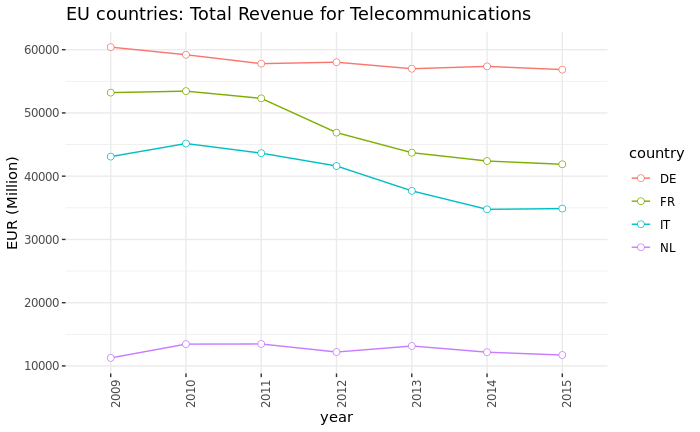

```r
# - wrangle total_revenues
total_revenues$subject <-
  gsub("http://semantic.digital-agenda-data.eu/data/digital-agenda-scoreboard-key-indicators/tel_rev/total_tel/million_euro/",
       "",
       total_revenues$subject)
total_revenues <- total_revenues %>%
  separate(col = "subject",
           sep = "/",
           into = c("country", "year")) %>%
  filter(str_detect(predicate, "obsValue")) %>%
  select(-predicate)
total_revenues$object <- as.numeric(total_revenues$object)
total_revenues <- filter(total_revenues,
                         country %in% c("NL", "DE", "FR", "IT"))
ggplot(total_revenues, aes(x = year,
                           y = object,
                           group = country,
                           color = country,
                           fill = country)) +
  geom_line() +
  geom_point(size = 2) +
  geom_point(size = 1.5, color = "white") +
  ggtitle("EU countries: Total Revenue for Telecommunications") +
  ylab("EUR (Million)") +
  theme_bw() +
  theme(panel.border = element_blank()) +
  theme(axis.text.x = element_text(angle = 90))
```

We can obtain the same from a smarter SPARQL query:

```r
# - for <http://purl.org/linked-data/sdmx>, see: https://lov.linkeddata.es/dataset/lov/vocabs/sdmx
sparqlQuery <-
  'PREFIX measure:<http://purl.org/linked-data/sdmx/2009/measure#>
   SELECT ?country ?revenue
    WHERE {?country measure:obsValue ?revenue . }'

total_revenues_0 <- rdf_query(rdf_web,
                              query = sparqlQuery,
                              data.frame = T)
print(total_revenues_0)
```

| country | revenue |
| --- | --- |
| http://semantic.digital-agenda-data.eu/data/digital-agenda-scoreboard-key-indicators/tel_rev/total_tel/million_euro/CZ/2010 | 5307.360 |
| http://semantic.digital-agenda-data.eu/data/digital-agenda-scoreboard-key-indicators/tel_rev/total_tel/million_euro/CZ/2012 | 4608.300 |
| http://semantic.digital-agenda-data.eu/data/digital-agenda-scoreboard-key-indicators/tel_rev/total_tel/million_euro/UK/2010 | 42417.100 |
| http://semantic.digital-agenda-data.eu/data/digital-agenda-scoreboard-key-indicators/tel_rev/total_tel/million_euro/CZ/2013 | 3904.900 |
| http://semantic.digital-agenda-data.eu/data/digital-agenda-scoreboard-key-indicators/tel_rev/total_tel/million_euro/SI/2010 | 1094.790 |
| http://semantic.digital-agenda-data.eu/data/digital-agenda-scoreboard-key-indicators/tel_rev/total_tel/million_euro/IE/2012 | 4150.390 |
| http://semantic.digital-agenda-data.eu/data/digital-agenda-scoreboard-key-indicators/tel_rev/total_tel/million_euro/SK/2011 | 2180.000 |
| http://semantic.digital-agenda-data.eu/data/digital-agenda-scoreboard-key-indicators/tel_rev/total_tel/million_euro/EU/2012 | 323296.000 |
| http://semantic.digital-agenda-data.eu/data/digital-agenda-scoreboard-key-indicators/tel_rev/total_tel/million_euro/LV/2012 | 393.000 |
| http://semantic.digital-agenda-data.eu/data/digital-agenda-scoreboard-key-indicators/tel_rev/total_tel/million_euro/UK/2014 | 49777.900 |

[output cut: 191 more lines]

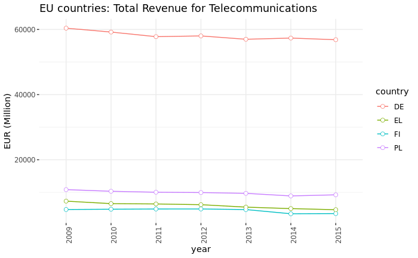

```r
# - wrangle total_revenues
total_revenues_0$country <-
  gsub("http://semantic.digital-agenda-data.eu/data/digital-agenda-scoreboard-key-indicators/tel_rev/total_tel/million_euro/",
       "",
       total_revenues_0$country)
total_revenues_0 <- total_revenues_0 %>%
  separate(col = "country",
           sep = "/",
           into = c("country", "year"))
total_revenues_0 <- filter(total_revenues_0,
                         country %in% c("EL", "FI", "DE", "PL"))
ggplot(total_revenues_0, aes(x = year,
                             y = revenue,
                             group = country,
                             color = country,
                             fill = country)) +
  geom_line() +
  geom_point(size = 2) +
  geom_point(size = 1.5, color = "white") +
  ggtitle("EU countries: Total Revenue for Telecommunications") +
  ylab("EUR (Million)") +
  theme_bw() +
  theme(panel.border = element_blank()) +
  theme(axis.text.x = element_text(angle = 90))
```

```r
# - clean up (!)
rdf_free(rdf_web)
```

### 4.2 Wikidata JSON from Wikidata Query Service (SPARQL end-point)

```r
wdqs_endpoint = 'https://query.wikidata.org/sparql?format=json&query='
sparqlQuery <- 'SELECT ?city ?cityLabel ?coordinate ?population ?date
  WHERE {?city wdt:P31 wd:Q515 .
         ?city wdt:P17 wd:Q38 .
         ?city wdt:P625 ?coordinate .
         ?city p:P1082 ?populationStatement .
         ?populationStatement ps:P1082 ?population;
                              pq:P585 ?date .
         SERVICE wikibase:label { bd:serviceParam wikibase:language "en". }
         }'
sparqlQuery <- paste0(wdqs_endpoint, sparqlQuery)
sparqlQuery <- URLencode(sparqlQuery)
cat(sparqlQuery)
```

```
https://query.wikidata.org/sparql?format=json&query=SELECT%20?city%20?cityLabel%20?coordinate%20?population%20?date%0A%20%20WHERE%20%7B?city%20wdt:P31%20wd:Q515%20.%0A%20%20%20%20%20%20%20%20%20?city%20wdt:P17%20wd:Q38%20.%0A%20%20%20%20%20%20%20%20%20?city%20wdt:P625%20?coordinate%20.%0A%20%20%20%2…
```

```r
res <- httr::GET(url = sparqlQuery)
cities <- rawToChar(res$content)
cities <- fromJSON(cities, simplifyDataFrame = T)
cities <- flatten(cities$results$bindings)
cities <- cities %>%
  select(cityLabel.value, population.value,
         date.value, coordinate.value)
cities$population.value <- as.numeric(cities$population.value)
head(cities, 10)
```

|  | cityLabel.value | population.value | date.value | coordinate.value |
| --- | --- | --- | --- | --- |
| 1 | Savona | 61057 | 2017-01-01T00:00:00Z | Point(8.481016666 44.307975) |
| 2 | Savona | 60632 | 2018-01-01T00:00:00Z | Point(8.481016666 44.307975) |
| 3 | Savona | 61227 | 2016-06-30T00:00:00Z | Point(8.481016666 44.307975) |
| 4 | Piacenza | 102181 | 2016-06-30T00:00:00Z | Point(9.7 45.05) |
| 5 | Piacenza | 103082 | 2018-01-01T00:00:00Z | Point(9.7 45.05) |
| 6 | Piacenza | 102355 | 2017-01-01T00:00:00Z | Point(9.7 45.05) |
| 7 | Reggio nell’Emilia | 170996 | 2016-06-30T00:00:00Z | Point(10.633333333 44.7) |
| 8 | Reggio nell’Emilia | 171944 | 2018-01-01T00:00:00Z | Point(10.633333333 44.7) |
| 9 | Ferrara | 132445 | 2016-06-30T00:00:00Z | Point(11.619865 44.835297) |
| 10 | Ferrara | 132278 | 2018-01-01T00:00:00Z | Point(11.619865 44.835297) |

Change in the population of Italian cities:

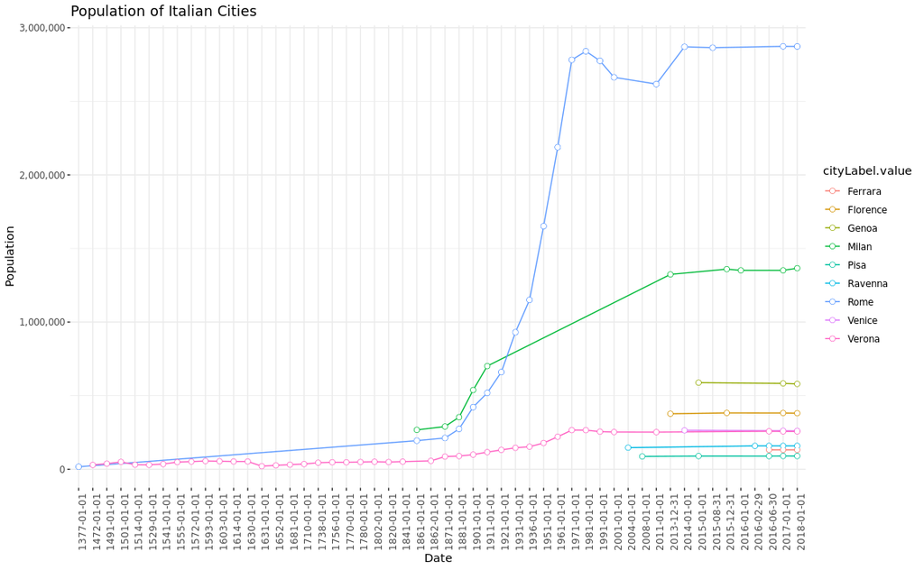

```r
citiesPopulation <- cities %>%
  select(cityLabel.value, population.value, date.value) %>%
  mutate(date.value = str_sub(date.value, 1, 10)) %>%
  arrange(cityLabel.value, desc(population.value), desc(date.value)) %>%
  filter(!str_detect(date.value, "^-"))
searchQuery <- c('Rome', 'Milan', 'Genoa',
                 'Florence', 'Ravenna', 'Ferrara',
                 'Pisa', 'Verona', 'Venice')
citiesPopulation <- citiesPopulation %>%
  filter(cityLabel.value %in% searchQuery)
ggplot(citiesPopulation, aes(x = date.value,
                             y = population.value,
                             group = cityLabel.value,
                             color = cityLabel.value,
                             fill = cityLabel.value)) +
  geom_line() +
  geom_point(size = 2) +
  geom_point(size = 1.5, color = "white") +
  scale_y_continuous(labels = comma) +
  ggtitle("Population of Italian Cities") +
  ylab("Population") + xlab("Date") +
  theme_bw() +
  theme(panel.border = element_blank()) +
  theme(axis.text.x = element_text(angle = 90, size = 9))
```

Locate cities:

```r
citiesMap <- cities %>%
  select(cityLabel.value, coordinate.value) %>%
  distinct()
coordinates <- str_extract_all(citiesMap$coordinate.value, '([[:digit:]]|\\.)+')
coordinates <- as.data.frame(do.call(rbind, coordinates), stringsAsFactors = F)
colnames(coordinates) <- c('lng', 'lat')
citiesMap <- cbind(citiesMap, coordinates) %>%
  select(cityLabel.value, lat, lng)
citiesMap$lat <- round(as.numeric(coordinates$lat), 2)
citiesMap$lng <- round(as.numeric(coordinates$lng), 2)
leaflet() %>%
  addProviderTiles(providers$CartoDB.Positron) %>%
  addMarkers(data = cities,
             lng = citiesMap$lng,
             lat = citiesMap$lat,
             popup = paste('<b>', citiesMap$cityLabel.value, '</b><br>',
                            "Lat: ", citiesMap$lng, '<br>',
                            "Lon: ", citiesMap$lat, '<br>'),
                      clusterOptions = markerClusterOptions()
  )
```

[interactive chart not shown]

### 4.2 DBpedia through {SPARQL}

The [{SPARQL}](https://cran.r-project.org/web/packages/SPARQL/index.html) package is useful in interaction with SPARQL endpoints. It exposes one function, `SPARQL:SPARQL()` to connect to an endpoint, and has a built-in vector of common namespaces and their prefixes:

```r
print(SPARQL::commonns)
```

```
 [1] "xsd"                                           "<http://www.w3.org/2001/XMLSchema#>"           "rdf"
 [4] "<http://www.w3.org/1999/02/22-rdf-syntax-ns#>" "rdfs"                                          "<http://www.w3.org/2000/01/rdf-schema#>"
 [7] "owl"                                           "<http://www.w3.org/2002/07/owl#>"              "skos"
[10] "<http://www.w3.org/2004/02/skos/core#>"        "dc"                                            "<http://purl.org/dc/elements/1.1/>"
[13] "foaf"                                          "<http://xmlns.com/foaf/0.1/>"                  "wgs84"
[16] "<http://www.w3.org/2003/01/geo/wgs84_pos#>"    "qb"                                            "<http://purl.org/linked-data/cube#>"
```

`SPARQL:SPARQL()` returns a nicely formatted data.frame populated by the values of query variables. Let’s use {SPARQL} to connect to [DBpedia](https://wiki.dbpedia.org/): fetch Italian cities with more than 10,000 inhabitants and their names in Italian.

```r
dbpedia_endpoint <- 'http://dbpedia.org/sparql'
sparqlQuery <-"prefix dbpedia: <http://dbpedia.org/resource/>
               prefix dbpedia-owl: <http://dbpedia.org/ontology/>
               SELECT DISTINCT ?cityURI ?city ?population ?latitude ?longitude
                 WHERE {
                   ?cityURI dbpedia-owl:country dbpedia:Italy .
                   ?cityURI geo:lat  ?latitude .
                   ?cityURI geo:long  ?longitude .
                   ?cityURI rdfs:label ?city .
                   ?cityURI dbpedia-owl:populationTotal ?population .
                   FILTER (lang(?city) = 'it') .
                   FILTER (?population > 10000) .
                 }"
res <- SPARQL(url = dbpedia_endpoint,
              query = sparqlQuery)
print(str(res))
```

```
List of 2
 $ results   :'data.frame': 1373 obs. of  5 variables:
  ..$ cityURI   : chr [1:1373] "<http://dbpedia.org/resource/Virgilio,_Lombardy>" "<http://dbpedia.org/resource/Bologna>" "<http://dbpedia.org/resource/Carbonera,_Veneto>" "<http://dbpedia.org/resource/Montoro,_Campania>" ...
  ..$ city      : chr [1:1373] "\"Virgilio (Italia)\"@it" "\"Bologna\"@it" "\"Carbonera\"@it" "\"Montoro (Italia)\"@it" ...
  ..$ population: int [1:1373] 11282 387554 11180 19668 52774 12080 28755 17084 10014 24088 ...
  ..$ latitude  : num [1:1373] 45.1 44.5 45.7 40.8 43.3 ...
  ..$ longitude : num [1:1373] 10.8 11.4 12.3 14.8 11.3 ...
 $ namespaces: NULL
NULL
```

**Note.** I did not even define `PREFIX rdfs:<http://www.w3.org/2000/01/rdf-schema#>` (as used in the `?city rdfs:label ?cityName .` constraint in the query) or `PREFIX geo:< http://www.w3.org/2003/01/geo/wgs84_pos#>` (as used in`?city geo:lat ?latitude .` constraint); see: [DBpedia predefined prefixes](http://fr.dbpedia.org/sparql?nsdecl).

Locate places: the results our found in `res$results`

```r
places <- res$results %>%
  select(city, population, latitude, longitude) %>%
  arrange(desc(population))
print(places)
```

| city | population | latitude | longitude |
| --- | --- | --- | --- |
| "Penisola italiana"@it | 26171000 | 42.0000 | 14.00000 |
| "Lazio"@it | 5891582 | 41.9000 | 12.71670 |
| "Sicilia"@it | 5077487 | 37.5000 | 14.00000 |
| "Emilia-Romagna"@it | 4429766 | 44.5106 | 10.95690 |
| "Provincia di Roma"@it | 4336251 | 41.8931 | 12.48280 |
| "Città metropolitana di Roma Capitale"@it | 4333689 | 41.8931 | 12.48280 |
| "Puglia"@it | 4045949 | 41.0086 | 16.51280 |
| "Città metropolitana di Milano"@it | 3206465 | 45.4642 | 9.19030 |
| "Provincia di Milano"@it | 3195211 | 45.4642 | 9.19034 |
| "Città metropolitana di Napoli"@it | 3128700 | 40.8333 | 14.25000 |

[output cut: 990 more lines]

```r
places$latitude <- round(places$latitude, 2)
places$longitude <- round(places$longitude, 2)
leaflet() %>%
  addProviderTiles(providers$CartoDB.Positron) %>%
  addMarkers(data = places,
             popup = paste('<b>', places$city, '</b><br>',
                            "Population: ", places$population, '<br>',
                            "Lat: ", places$latitude, '<br>',
                            "Lon: ", places$longitude, '<br>'),
                      clusterOptions = markerClusterOptions()
  )
```

[interactive chart not shown]

## Resources

- [RDF 1.1 Primer (W3C Working Group Note 24 June 2014)](https://www.w3.org/TR/rdf11-primer/)
- [LINKED DATA from W3C](https://www.w3.org/standards/semanticweb/data)
- [Wikidata:SPARQL tutorial](https://www.wikidata.org/wiki/Wikidata:SPARQL_tutorial)
- [Wikidata:SPARQL query service/A gentle introduction to the Wikidata Query Service](https://www.wikidata.org/wiki/Wikidata:SPARQL_query_service/A_gentle_introduction_to_the_Wikidata_Query_Service)
- SPARQL query examples for Wikidata:
  - [Wikidata:SPARQL query service/queries/examples](https://www.wikidata.org/wiki/Wikidata:SPARQL_query_service/queries/examples)
  - [Wikidata:SPARQL query service/queries](https://www.wikidata.org/wiki/Wikidata:SPARQL_query_service/queries)
- [A tidyverse lover’s intro to RDF](https://cran.r-project.org/web/packages/rdflib/vignettes/rdf_intro.html#fn2) - Carl Boettiger’s [{rdflib}](https://cran.r-project.org/web/packages/rdflib/index.html) vignette
- [Linked Open Data on DataHub.io](https://datahub.io/collections/linked-open-data)

Goran S. Milovanović, Phd

DataKolektiv, 2020.

contact: goran.milovanovic@datakolektiv.com

License: [GPLv3](http://www.gnu.org/licenses/gpl-3.0.txt) This Notebook is free software: you can redistribute it and/or modify it under the terms of the GNU General Public License as published by the Free Software Foundation, either version 3 of the License, or (at your option) any later version. This Notebook is distributed in the hope that it will be useful, but WITHOUT ANY WARRANTY; without even the implied warranty of MERCHANTABILITY or FITNESS FOR A PARTICULAR PURPOSE. See the GNU General Public License for more details. You should have received a copy of the GNU General Public License along with this Notebook. If not, see http://www.gnu.org/licenses/.